# Thijmens CV

## 2.2 Checking reproducability possibility for published papers.

in this assignment, this study [@stroblPositiveCorrelationPesticide2020] will be graded on the criteria for reproducibility.

### 2.2.1 introduction to this article

the use of pesticides is one of the main reasons of loss of biodiversity, and the combination of multiple pesticides could even make this worse. in this experiment it is investigated what the sublethal (food consumption) and the lethal (survival) effects of pesticides are on adult female solitary bees, *Osmia bicornis*.  
to perform these tests, female solitary bees were divided into 4 groups:  
pesticide free (control) herbicide pesticide combined (both herbicide and pesticide) their consumption rate and longevity were measured and the data from these two variables are used for analysis.  
their is no significant difference in survival and consumption between te different groups. there is however a significant positive correlation between the consumption rate and the longevity of these bees.

### 2.2.2 grading of this experiment on the transparancy criteria

| transparancy criteria | grading |
| --- | --- |
| study purpose | TRUE |
| data availability | FALSE only part of the data is available |
| data location | at the beginning/ at the end |
| study location | TRUE materials/methods |
| author review | location and email are present at the top |
| ethics statement | FALSE |
| funding statement | TRUE |
| code availability | TRUE |

The part of the data that is available can be accessed through this directory: “data/insects-957898-supplementary.xlsx”

## 2.3 organisation of my files

to show my ability at organizing files heres an example of the file structure from one of my previous projects

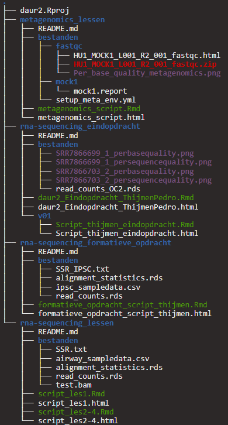

[figure not shown]